# ADA-PARC State Scorecard

# Illinois

ADA-PARC Scorecard · 2024 Data

[figure not shown]

Overall ADA-PARC Score

Overall

#41

of 51

Poor

Community Living

#44

of 51

Poor

Community Participation

#24

of 51

Above Average

Work & Economic

#22

of 51

Above Average

## Community Living

34.8

Score

US avg: 50.0

Rank #44 of 51 · Poor

### Sub-Index Scores

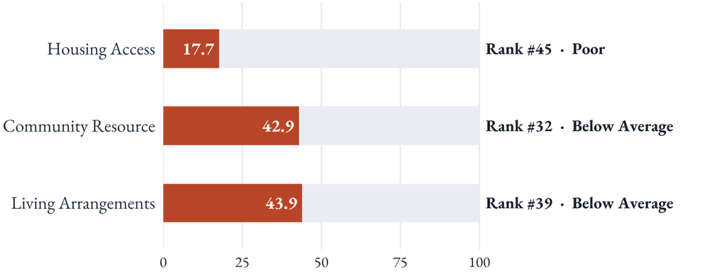

## Community Participation

50.9

Score

US avg: 48.8

Rank #24 of 51 · Above Average

### Sub-Index Scores

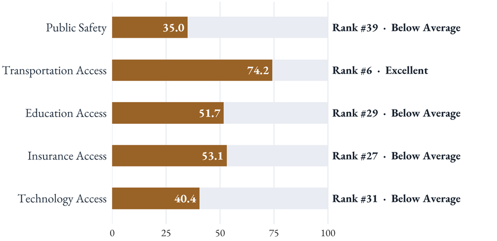

## Work & Economic

56.4

Score

US avg: 44.6

Rank #22 of 51 · Above Average

### Sub-Index Scores

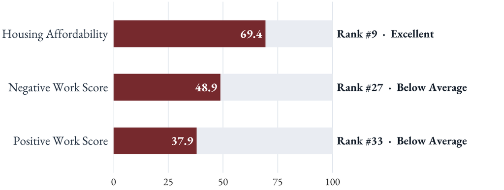

### Score Summary

| Index / Sub-Index | Illinois | US Average | Rank | Tier |
| --- | --- | --- | --- | --- |
| Overall ADA-PARC | 45.8 | 49.9 | #41 | Poor |
| Community Living | 34.8 | 50.0 | #44 | Poor |
| Living Arrangements | 43.9 | 49.2 | #39 | Below Average |
| Community Resources | 42.9 | 49.5 | #32 | Below Average |
| Housing Access | 17.7 | 48.5 | #45 | Poor |
| Community Participation | 50.9 | 48.8 | #24 | Above Average |
| Technology Access | 40.4 | 53.1 | #31 | Below Average |
| Education Access | 51.7 | 42.3 | #29 | Below Average |
| Insurance Access | 53.1 | 45.5 | #27 | Below Average |
| Transportation Access | 74.2 | 54.2 | #6 | Excellent |
| Public Safety | 35.0 | 52.3 | #39 | Below Average |
| Work & Economic | 56.4 | 44.6 | #22 | Above Average |
| Positive Work Score | 37.9 | 41.1 | #33 | Below Average |
| Negative Work Score | 48.9 | 48.2 | #27 | Below Average |
| Housing Affordability | 69.4 | 50.0 | #9 | Excellent |

Scores range 0–100; higher is better. Rankings among all U.S. states and territories with available data. Puerto Rico may show — for PUMS-sourced indices.

### About ADA-PARC Categories

**Community Living**

The degree to which people with disabilities (aged 18–64) live in community settings rather than nursing homes or correctional facilities, and whether states invest in community-based housing resources.

**Community Participation**

Access to the tools and systems that enable full participation in community life — including technology, health insurance, educational attainment, transportation, and public safety.

**Work & Economic**

Economic inclusion and security for people with disabilities — measuring positive work outcomes (employment, income), negative labor force indicators (poverty, unemployment, NILF), and housing affordability.

ADA-PARC Scorecard · 2024 Data · Scores range 0–100; higher is better. · Rankings among 51 U.S. states and territories. · Rank tiers: **Excellent** (1–13) · **Above Average** (14–26) · **Below Average** (27–39) · **Poor** (40–52).